# Tarea_01

FES Acatlán

septiembre de 2021

#### Fecha de entrega

Fecha límite de entrega: domingo 26 de septiembre de 2021 a las 11:59 pm. Enviar solución al mail: leonardo.marintellez@gmail.com

### Tarea

Utilizaremos los datos de la Encuesta ENIGH 2018.

La Encuesta Nacional de Ingresos y Gastos de los Hogares 2018 se llevó a cabo del 21 de agosto al 28 de noviembre de 2018. Su objetivo es proporcionar un panorama estadístico del comportamiento de los **ingresos y gastos de los hogares** en cuanto a su monto, procedencia y distribución; adicionalmente, ofrece información sobre las características ocupacionales y sociodemográficas de los integrantes del hogar, así como las características de la infraestructura de la vivienda y el equipamiento del hogar.

Los datos utilizados pueden ser encontardos en la liga del repositorio o en la siguiente página en la cual encontrarán mucho más detalle de los mismos.

[ENIGH 2018](https://www.inegi.org.mx/programas/enigh/nc/2018/#Microdatos).

```r
# Limpiar área de trabajo
rm(list = ls())
```

```r
# Cargar librerías
suppressMessages(library(tidyverse))
library(ggplot2)
library(readr)
library(stringr)
```

Leer los datos

```r
enigh_2018 <- read_csv("~/Documentos/Acatlan/datos/ENIGH_2018/conjunto_de_datos_concentradohogar_enigh_2018_ns.csv", col_types = cols(folioviv = col_character(), ubica_geo = col_character() ))
```

Sólo conservar ciertas variables ya que no ocuparemos todas. Adicionalmente crearemos una variable para identificar la entidad federativa. Usualmente el INEGI usa una variable tipo carácter de longitud 5 para identificar estado y municipio, los primeros 2 dígitos son la entidad y los últimos 3 son el municipio.

Descripción de las variables:

- folioviv: Identificador de la vivienda.
- foliohog: Código que identifica el hogar.
- ubica_geo: Contiene la ubicación geográfica de la vivienda. Los primeros 2 dígitos representan la clave de la entidad y los siguientes 3 la clave del municipio.
- ing_cor: Ingreso (corriente) trimestral del hogar.
- gasto_mon: Gasto (corriente monetario) trimestral del hogar.

```r
datos <- enigh_2018 %>% select(folioviv,foliohog, ubica_geo, est_dis, upm, factor, ing_cor, gasto_mon) %>%
        mutate(edo_mun = str_pad(ubica_geo,width = 5,side = "left",pad = "0"),
               cve_edo = substr(edo_mun,1,2))

glimpse(datos)
```

```
## Rows: 74,647
## Columns: 10
## $ folioviv  <chr> "100013601", "100013602", "100013603", "100013604", "1…
## $ foliohog  <dbl> 1, 1, 1, 1, 1, 1, 1, 1, 1, 1, 1, 1, 1, 1, 1, 1, 1, 1, …
## $ ubica_geo <chr> "1001", "1001", "1001", "1001", "1001", "1001", "1001"…
## $ est_dis   <dbl> 2, 2, 2, 2, 2, 2, 2, 2, 2, 2, 2, 2, 2, 2, 2, 2, 2, 2, …
## $ upm       <dbl> 1, 1, 1, 1, 1, 2, 2, 2, 2, 3, 3, 3, 3, 4, 4, 4, 4, 4, …
## $ factor    <dbl> 175, 175, 175, 175, 175, 189, 189, 189, 189, 186, 186,…
## $ ing_cor   <dbl> 76403.70, 42987.73, 580697.74, 46252.71, 53837.09, 237…
## $ gasto_mon <dbl> 18551.47, 55470.99, 103106.89, 19340.06, 13605.03, 336…
## $ edo_mun   <chr> "01001", "01001", "01001", "01001", "01001", "01001", …
## $ cve_edo   <chr> "01", "01", "01", "01", "01", "01", "01", "01", "01", …
```

### Ejercicios

0. Identifica que no haya duplicados.
1. Estima el ingreso promedio trimestral de los hogares. Reporta los siguientes 3 datos : Estimación, Error Estándar, Coeficiente de variación. Reflexiona lo siguiente: ¿esperaban ese dato de la estimación?.
2. Estima el gasto promedio trimestral de los hogares. Reporta los siguientes 3 datos : Estimación, Error Estándar, Coeficiente de variación.

El **coeficiente de variación** para una muestra se define de la siguiente manera

$$cv(\hat{\theta})= \frac{(\hat{V}(\hat{\theta}))^\frac{1}{2}}{\hat{\theta}}$$

Es una medida que nos permite medir la variabilidad independientemente de la escala de las variables.

3. Hacer estimaciones de por Estado. ¿Cuáles son los 3 estados con ingreso más alto?. ¿Cuáles son los 3 estados con ingreso más bajo?. Si tuvieras que elegir una estimación para el ingreso promedio trimestral por hogar del estado de Chiapas ¿cual elegirías, tu estimación obtenida para ese estado en esta pregunta o la estimación de la pregunta 1?. Explica brevemente tu elección.

Las siguientes líneas le agregan el descriptivo a los códigos de los estados.

```r
cve_edo <-  str_pad(1:32, width = 2,side = "left",pad = "0")
desc_edo <- c("Aguascalientes", "Baja California", "Baja California Sur",
"Campeche", "Coahuila de Zaragoza", "Colima", "Chiapas", "Chihuahua", "Ciudad de México",
"Durango", "Guanajuato", "Guerrero", "Hidalgo", "Jalisco", "Estado de México", "Michoacán de Ocampo",
"Morelos", "Nayarit", "Nuevo León", "Oaxaca", "Puebla", "Querétaro", "Quintana Roo", "San Luis Potosí", "Sinaloa",
"Sonora", "Tabasco", "Tamaulipas", "Tlaxcala", "Veracruz de Ignacio de la Llave", "Yucatán", "Zacatecas")

catalogo_estados <- data_frame(cve_edo = cve_edo,desc_edo = desc_edo)
head(catalogo_estados)
```

```
## # A tibble: 6 x 2
##   cve_edo desc_edo
##   <chr>   <chr>
## 1 01      Aguascalientes
## 2 02      Baja California
## 3 03      Baja California Sur
## 4 04      Campeche
## 5 05      Coahuila de Zaragoza
## 6 06      Colima
```

```r
datos_con_estados <- left_join(datos,catalogo_estados, by = c("cve_edo"))
glimpse(datos_con_estados)
```

```
## Rows: 74,647
## Columns: 11
## $ folioviv  <chr> "100013601", "100013602", "100013603", "100013604", "1…
## $ foliohog  <dbl> 1, 1, 1, 1, 1, 1, 1, 1, 1, 1, 1, 1, 1, 1, 1, 1, 1, 1, …
## $ ubica_geo <chr> "1001", "1001", "1001", "1001", "1001", "1001", "1001"…
## $ est_dis   <dbl> 2, 2, 2, 2, 2, 2, 2, 2, 2, 2, 2, 2, 2, 2, 2, 2, 2, 2, …
## $ upm       <dbl> 1, 1, 1, 1, 1, 2, 2, 2, 2, 3, 3, 3, 3, 4, 4, 4, 4, 4, …
## $ factor    <dbl> 175, 175, 175, 175, 175, 189, 189, 189, 189, 186, 186,…
## $ ing_cor   <dbl> 76403.70, 42987.73, 580697.74, 46252.71, 53837.09, 237…
## $ gasto_mon <dbl> 18551.47, 55470.99, 103106.89, 19340.06, 13605.03, 336…
## $ edo_mun   <chr> "01001", "01001", "01001", "01001", "01001", "01001", …
## $ cve_edo   <chr> "01", "01", "01", "01", "01", "01", "01", "01", "01", …
## $ desc_edo  <chr> "Aguascalientes", "Aguascalientes", "Aguascalientes", …
```

4. **(opcional)**. (Ingreso vs Gasto) Hacer una grafica de dispersión del ingreso vs gasto por hogar para los hogares que tienen ingreso menor a la estimación obtenida en la primera pregunta.
5. **(opcional)**. Graficar los histogramas del ingreso y gasto en la misma grafica. Fijar el eje x de cero a 250 mil.

**Solución**

¿Cuántas viviendas y cuántos hogares hay en los datos?

```r
enigh_2018 %>%
  mutate(llave_hogar = paste(folioviv,foliohog,sep = "_")) %>%
  summarise(num_viv = n_distinct(folioviv), num_hog = n_distinct(llave_hogar), suma_factor = sum(factor))
```

```
## # A tibble: 1 x 3
##   num_viv num_hog suma_factor
##     <int>   <int>       <dbl>
## 1   73405   74647    34744818
```

¿Cuántas viviendas y cuántos hogares hay en la muestra por estado?. ¿Qué estado tiene mayor número de muestra?

```r
datos %>% group_by(cve_edo) %>%
  mutate(llave_hogar = paste(folioviv,foliohog,sep = "_")) %>%
  summarise(num_viv = n_distinct(folioviv), num_hog = n_distinct(llave_hogar), suma_factor = sum(factor)) %>%
  arrange(desc(num_hog))
```

```
## # A tibble: 32 x 4
##    cve_edo num_viv num_hog suma_factor
##    <chr>     <int>   <int>       <dbl>
##  1 08         3772    3784     1151023
##  2 02         3306    3322     1078478
##  3 05         3160    3186      846952
##  4 22         3028    3126      578509
##  5 19         3011    3043     1497190
##  6 25         2849    2887      865313
##  7 15         2811    2857     4773217
##  8 06         2726    2785      233679
##  9 11         2593    2658     1523467
## 10 31         2399    2463      608564
## # … with 22 more rows
```

Estimaciones

```r
enigh_2018 %>% summarise(promedio_ingreso = mean(ing_cor), sd_ingreso = sd(ing_cor),
                         promedio_gasto = mean(gasto_mon), sd_gasto = sd(gasto_mon))
```

```
## # A tibble: 1 x 4
##   promedio_ingreso sd_ingreso promedio_gasto sd_gasto
##              <dbl>      <dbl>          <dbl>    <dbl>
## 1           46044.     61234.         28990.   28436.
```

Recordar que el error estándar es la raiz de (var(x)/n)

```r
ee_ingreso <- 61234.05 / sqrt(74647)
ee_ingreso
```

```
## [1] 224.1232
```

```r
ee_gasto <- 28435.68 / sqrt(74647)
ee_gasto
```

```
## [1] 104.0776
```

Coeficiente de variación

```r
224.12/46044
```

```
## [1] 0.004867518
```

```r
104.08/28990.03
```

```
## [1] 0.0035902
```

**Solución usando la librería survey**

```r
suppressMessages(library(survey))
```

**Muestreo Aleatorio simple**

Definir diseño

```r
disenio_mas <-svydesign(id=~1, weights=~1,data=datos)
```

Estimación

```r
promedio_ingreso <-  svymean(~ing_cor,disenio_mas)
promedio_ingreso
```

```
##          mean     SE
## ing_cor 46044 224.12
```

```r
promedio_gasto <-  svymean(~gasto_mon,disenio_mas, deff = TRUE)
promedio_gasto
```

```
##               mean       SE DEff
## gasto_mon 28990.03   104.08  Inf
```

Coeficiente de variación

```r
cv(promedio_ingreso)
```

```
##             ing_cor
## ing_cor 0.004867601
```

```r
cv(promedio_gasto)
```

```
##             gasto_mon
## gasto_mon 0.003590118
```

Intervalos de Confianza

```r
confint(promedio_ingreso,level=0.90)
```

```
##              5 %     95 %
## ing_cor 45675.23 46412.53
```

```r
confint(promedio_ingreso,level=0.95)
```

```
##           2.5 %   97.5 %
## ing_cor 45604.6 46483.15
```

```r
confint(promedio_gasto,level=0.90)
```

```
##                5 %     95 %
## gasto_mon 28818.84 29161.23
```

```r
confint(promedio_gasto,level=0.95)
```

```
##              2.5 %   97.5 %
## gasto_mon 28786.04 29194.02
```

**Diseño ENIGH**

```r
disenio_enigh<-svydesign(id=~upm, strata=~est_dis, weights=~factor,data=datos)
```

```r
estimacion_ingreso <- svymean(~ing_cor,disenio_enigh, deff = TRUE)
estimacion_ingreso
```

```
##             mean       SE   DEff
## ing_cor 49610.29   443.92 3.4015
```

```r
estimacion_gasto <- svymean(~gasto_mon,disenio_enigh, deff= TRUE)
estimacion_gasto
```

```
##               mean       SE   DEff
## gasto_mon 31912.74   240.69 3.8407
```

```r
confint(estimacion_ingreso,level=0.90)
```

```
##              5 %     95 %
## ing_cor 48880.11 50340.48
```

```r
confint(estimacion_gasto,level=0.90)
```

```
##                5 %     95 %
## gasto_mon 31516.84 32308.64
```

```r
49610 + qnorm(0.95)*443.92
```

```
## [1] 50340.18
```

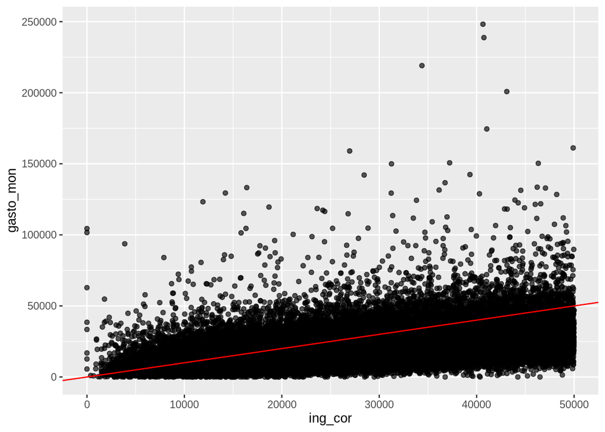

```r
ggplot(data = enigh_2018 %>% filter(ing_cor < 50000)) +
  geom_point(mapping = aes(x = ing_cor, y = gasto_mon), alpha = 0.65) +
   geom_abline(intercept=0, slope=1.0, colour = "red")
```

¿Cuántos casos hay donde gasto sea mayor que ingreso

```r
enigh_2018 %>% filter(gasto_mon > ing_cor) %>% select(gasto_mon,ing_cor) %>% glimpse()
```

```
## Rows: 13,870
## Columns: 2
## $ gasto_mon <dbl> 55470.99, 33310.57, 41265.35, 64954.98, 41964.88, 4746…
## $ ing_cor   <dbl> 42987.73, 32606.55, 28800.64, 60344.49, 28155.72, 4476…
```

3. Hacer estimaciones de por Estado. ¿Cuáles son los 3 estados con ingreso más alto?. ¿Cuáles son los 3 estados con ingreso más bajo?.

```r
estimacion_x_estado <- datos_con_estados %>% group_by(cve_edo, desc_edo) %>%
  summarise(promedio_ingreso = mean(ing_cor), sd_ingreso = sd(ing_cor),
                         promedio_gasto = mean(gasto_mon), sd_gasto = sd(gasto_mon)) %>%
  arrange(desc(promedio_ingreso))
head(estimacion_x_estado)
```

```
## # A tibble: 6 x 6
## # Groups:   cve_edo [6]
##   cve_edo desc_edo      promedio_ingreso sd_ingreso promedio_gasto sd_gasto
##   <chr>   <chr>                    <dbl>      <dbl>          <dbl>    <dbl>
## 1 09      Ciudad de Mé…           67466.     87853.         40146.   48107.
## 2 03      Baja Califor…           64987.    126215.         35293.   32397.
## 3 01      Aguascalient…           57622.     69678.         34993.   30625.
## 4 25      Sinaloa                 56615.     80422.         33220.   28707.
## 5 14      Jalisco                 55924.     63096.         36684.   36608.
## 6 26      Sonora                  54230.     50991.         31016.   29119.
```

```r
tail(estimacion_x_estado)
```

```
## # A tibble: 6 x 6
## # Groups:   cve_edo [6]
##   cve_edo desc_edo      promedio_ingreso sd_ingreso promedio_gasto sd_gasto
##   <chr>   <chr>                    <dbl>      <dbl>          <dbl>    <dbl>
## 1 32      Zacatecas               38210.     45402.         26620.   26460.
## 2 21      Puebla                  37537.     35114.         26312.   20473.
## 3 20      Oaxaca                  29967.     56037.         19011.   17833.
## 4 30      Veracruz de …           29177.     28900.         21262.   18690.
## 5 12      Guerrero                27678.     29782.         20776.   17798.
## 6 07      Chiapas                 26107.     26081.         18782.   17144.
```

Grafica de Barras horizontales de mayor a menor.

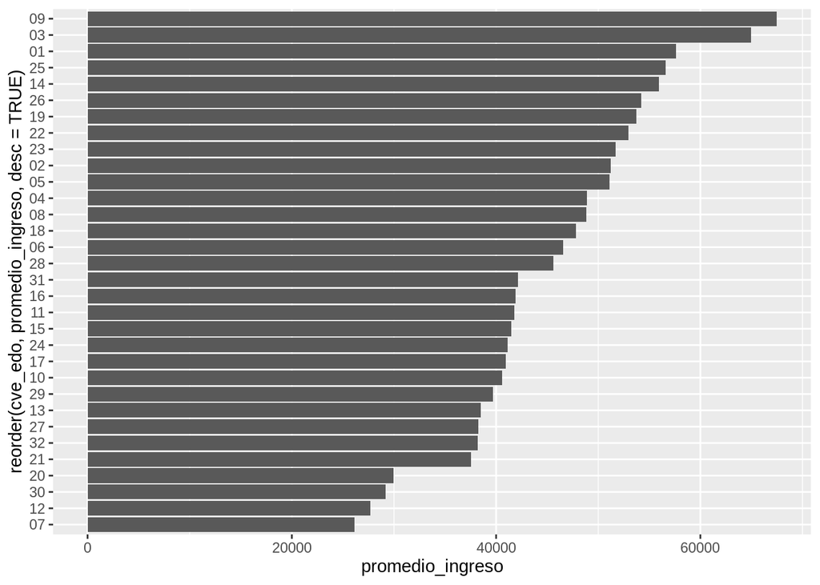

```r
ggplot(data = estimacion_x_estado) +
geom_col(mapping = aes(x = reorder(cve_edo,promedio_ingreso, desc = TRUE), y = promedio_ingreso)) +
coord_flip()
```

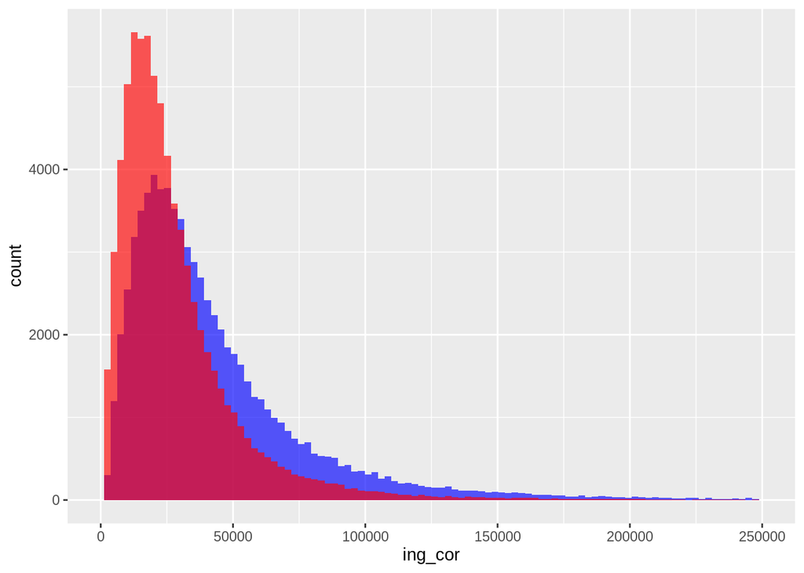

```r
ggplot(data = datos) +
  geom_histogram(mapping = aes(x = ing_cor), alpha = 0.65, bins = 100, fill = "blue") +
  geom_histogram(mapping = aes(x = gasto_mon), alpha = 0.65, bins = 100, fill = "red") +
  scale_x_continuous(limits = c(0,250000))
```